# Character Classification[Source to this project](https://github.com/sanjeet12/Machine-Learning/tree/master/Devanagari%20Character%20Classification)

In this project i am going to implement a Convolutional Neural Network in keras framework for **Creating a classifier that can predict the character represented by any input image.** For performing this task I am using **Devanagari Handwritten Character Dataset.** Avalible [here](https://archive.ics.uci.edu/ml/datasets/Devanagari+Handwritten+Character+Dataset) for download.

Folder Organization Requirement for this project:

```
Character Classification
   |....Dataset
           |.....Train
           |.....Test
   |....Main.py or Main.ipynb
```

Dataset Description:

[output not shown]

### Architecture of CNN Used

```python
from IPython.display import Image
Image(url='head.png')
```

[figure not shown]

#### Importing the required Libraries

```python
#importing requiredlibraries
from __future__ import print_function
import keras
from keras.models import Sequential
from keras.layers import Dense, Dropout, Flatten
from keras.layers import Conv2D, MaxPooling2D
```

#### Image Preprocessing

Generating batches of tensor image data with real-time data augmentation like performing operations like shear, zoom, flip and rescaling to the training images. So that our model will learn the training images properly from all perspective in order to avoid the mis-classification just because of the position/orientation/zoom_out/zoom_in of character in the input image.

#### prepare the training_set

```python
#import keras image preprocessing library
from keras.preprocessing.image import ImageDataGenerator

#applying augmentation in the training dataset
train_datagen = ImageDataGenerator(rescale = 1./255,
shear_range = 0.2,
zoom_range = 0.2,
horizontal_flip = True)

#read the training images from the directory and apply the above augmentation
training_set = train_datagen.flow_from_directory('Dataset/Train',
target_size = (32, 32),
batch_size = 32)
```

```
Found 78200 images belonging to 46 classes.
```

#### prepare the test_set

```python
#normalize the pixel value to 0-1 of the test images
test_datagen = ImageDataGenerator(rescale = 1./255)

#read the test images from the directory and apply above augmentation
test_set = test_datagen.flow_from_directory('Dataset/Test',
target_size = (32,32),
batch_size = 32)
```

```
Found 13800 images belonging to 46 classes.
```

```python
#specifying the batch size and no of class for our model
batch_size = 100
num_classes = 46
```

#### Create the Convolution Neural Network Model

```python
#intialize the model of sequential type
model = Sequential()
#adding convolution layer with 32 filters of size 3*3 and with Rectified Linear Unit as activation function
model.add(Conv2D(32, kernel_size=(3, 3),activation='relu',input_shape=(32,32,3)))
#adding second convolution layer with 64 filters of size 3*3 and with Rectified Linear Unit as activation function
model.add(Conv2D(64, (3, 3), activation='relu'))
#now add maxpooling layer with pool size 2*2
model.add(MaxPooling2D(pool_size=(2, 2)))
#to avoide the overfitting of cnn by preventing complex co-adaptations on training data, we add dropout of 0.25
model.add(Dropout(0.25))
#convert the maxpooling layer 2d output to single dimension
model.add(Flatten())
#add dense layer which is nothing but the fully connected layer with previous layer the new layer with 128 neurons
model.add(Dense(128, activation='relu'))
#again add dropout to avoide overfitting
model.add(Dropout(0.5))
#finally add a dense layer with no of neurons equal to the number of classes we have here it is 46
model.add(Dense(num_classes, activation='softmax'))
```

#### Compile the Model

```python
# Compiling the CNN model with adam optimizer and since we have multiple class we will use categorical_crossentropy loss
model.compile(optimizer = 'adam', loss = 'categorical_crossentropy', metrics = ['accuracy'])
```

#### Train the Model on the training_set

```python
model.fit_generator(training_set,
steps_per_epoch = 782,
epochs = 10,
validation_data = test_set,
validation_steps = 200)
```

```
<keras.callbacks.History at 0x2277ebd7e80>
```

#### Save the trained Model for future utilization

```python
model.save('character_classification_devanagari.h5')
```

### Test on some input image

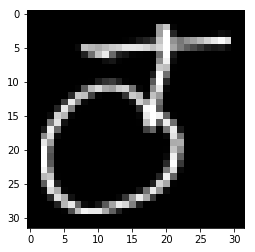

```python
%matplotlib inline
from keras.preprocessing import image
import matplotlib.pyplot as plt
import numpy as np
#load one test image which was not in training time and show it
testImage = image.load_img('Dataset/Test/character_12_thaa/347.png', target_size = (32, 32))
testImage = image.img_to_array(testImage)
plt.imshow(testImage/255.)
testImage = np.expand_dims(testImage, axis = 0)
```

### Show the all the classes

```python
classes = training_set.class_indices
print(classes)
```

[output not shown]

### Predict the class of the input image

```python
result = model.predict_classes(testImage)
print(result)
```

```
[14]
```

```python
for key,value in classes.items():
    if value == result:
        print("The class of the input Image : ",key)
```

```
The class of the input Image :  character_23_ba
```

### Loading the pretrained model and performing prediction [Transfer Learning]

```
The class of the input Image :  character_23_ba
```

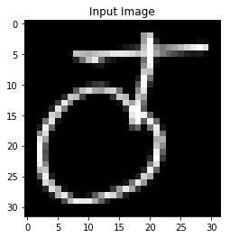

```python
#import the required libraries
%matplotlib inline
from keras.models import load_model
from keras.preprocessing import image
import matplotlib.pyplot as plt
import numpy as np

#load the pre-trained model
classifier = load_model('character_classification_devanagari.h5')

#compile the model with loss as categorical_crossentropy, optimizer as adam and metrics with accuracy
classifier.compile(loss='categorical_crossentropy',
              optimizer='adam',
              metrics=['accuracy'])

#load one test image which we want to test on the pre-trained model
testImage = image.load_img('Dataset/Test/character_12_thaa/347.png', target_size = (32, 32))
testImage = image.img_to_array(testImage)
plt.title("Input Image")
plt.imshow(testImage/255.)
testImage = np.expand_dims(testImage, axis = 0)

#predict the class of the test image
prediction = classifier.predict_classes(testImage)

for key,value in classes.items():
    if value == prediction:
        print("The class of the input Image : ",key)
```

## Sanjeet Kumar

Computer Science Engineer | sanjeetiiitd@gmail.com | 9741875443